# Practical Machine Learning Course Project

Darren Puigh

June 21, 2015

In the past decade, the number of wearable devices that monitor and record personal activity, e.g. smart phones, *Jawbone Up*, *Nike FuelBand*, *Fitbit*, etc., has increased dramatically. The majority of research using this data has focused on recognizing different activities. The goal for those studies is to see which activity is being performed and when. However, there is now a shifting emphasis for recognizing the quality of the activity. For this, one wants to see how well the activity is being done.

In this course project, we investigate a data set where participants were asked to perform dumbbell lifts correctly and incorrectly in five different ways (Velloso et al. 2013). Using data from accelerometers on the belt, forearm, arm, and dumbbell of six participants, our goal is to predict how well the activity was performed. The five different classifications of the quality of the activity are:

- 1. exactly according to the specification,
- 2. throwing the elbows to the front,
- 3. lifting the dumbbell only halfway,
- 4. lowering the dumbbell only halfway,
- 5. throwing the hips to the front.

# Getting and cleaning data

The training and testing data for this analysis can be found online:

```r
fileURL <- "https://d396qusza40orc.cloudfront.net/predmachlearn/pml-training.csv"
download.file(fileURL, "pml-training.csv", method="curl")
fileURL <- "https://d396qusza40orc.cloudfront.net/predmachlearn/pml-testing.csv"
download.file(fileURL, "pml-testing.csv", method="curl")
```

The data for this project come from this source: http://groupware.les.inf.puc-rio.br/har. Note that some of the columns in this data have different sorts of NA characters, namely “NA” and “#DIV/0!”. These can be identified when reading in the data:

```r
train <- read.csv("pml-training.csv", na.strings=c("NA","#DIV/0!"))
test <- read.csv("pml-testing.csv", na.strings=c("NA","#DIV/0!"))
```

Some variables contain many NA values (more than 90% of the rows). We identify and remove those rows, and we remove the first few rows that only contain subject or time data that would not be useful in predicting future outcomes:

```r
listColNAs <- sapply(train,function(x) sum(is.na(x))/nrow(train)<0.90)

train <- train[,listColNAs] %>%
    select(-(X:num_window))

test <- test[,listColNAs] %>%
    select(-(X:num_window))
```

We put the test data aside, and we will not come back to it until the end. The *train* data now has 19,622 observations of 53 variables (52 predictors and one outcome variable “classe”).

```r
dim(train)
```

```
## [1] 19622    53
```

# Variable selection and building the model

In principle, we could train with all 52 predictor variables. However, it is very likely that not all of these variables are useful, and we might be able to create a trained model with less variables that has a similar or better accuracy. To investigate this, we need to split our training set further to only use a portion of it for variable optimization. Note that this is mostly possible due to the large size of the training set (nearly 20,000). Were it much smaller, we might not be able to easily subdivide our training sample many times.

For variable investigations, we will use a random set of 5,000 observations (hereafter called “events”). Furthermore, we use 80% of events for training and 20% for testing:

```r
set.seed(1123)
forVarOpt <- sample(nrow(train), 5000)
trainVars <- train[forVarOpt,]
trainNoVars <- train[-forVarOpt,]

inTrainVars <- createDataPartition( y=trainVars$classe, p=0.8, list=FALSE )
trainingVars <- trainVars[ inTrainVars, ]
testingVars <- trainVars[ -inTrainVars, ]
```

```r
tc <- trainControl(method="cv", number=3)

cl <- makeCluster(detectCores())
registerDoParallel(cl)

modFit_Vars_rf <- train( classe ~ ., data=trainingVars, method="rf", trainControl=tc )
stopCluster(cl)
```

Next, we can look at the variables and their importance in their training for predicting the outcome:

```r
imp <- varImp(modFit_Vars_rf)$importance

imp$name <- row.names(imp)
imp <- imp[order(imp$Overall,decreasing=TRUE),]
print(imp, row.names=FALSE)
```

```
##      Overall                 name
##  100.0000000            roll_belt
##   58.0813036        pitch_forearm
##   53.5377113             yaw_belt
##   47.2249943    magnet_dumbbell_z
##   46.4215914         roll_forearm
##   44.9178271           pitch_belt
##   42.8418842    magnet_dumbbell_y
##   19.3390698        roll_dumbbell
##   19.1543388     accel_dumbbell_y
##   18.2418380    magnet_dumbbell_x
##   18.0457490        magnet_belt_z
##   17.8452352      accel_forearm_x
##   17.0896805     accel_dumbbell_z
##   16.2173809        magnet_belt_y
##   13.9735568     magnet_forearm_z
##   13.5671187         accel_belt_z
##   13.4562222        magnet_belt_x
##   12.8814888 total_accel_dumbbell
##    9.8358683         yaw_dumbbell
##    9.3143841              yaw_arm
##    9.0261775         gyros_belt_z
##    8.3272520      accel_forearm_z
##    7.9656613     accel_dumbbell_x
##    7.8976735     gyros_dumbbell_y
##    7.6511329     magnet_forearm_x
##    6.7703705             roll_arm
##    6.3887083     magnet_forearm_y
##    5.9249269         magnet_arm_y
##    5.3013401          accel_arm_x
##    4.7633162         magnet_arm_z
##    4.2544436       pitch_dumbbell
##    4.2356683          yaw_forearm
##    4.1527482          gyros_arm_y
##    3.9092209      accel_forearm_y
##    3.5898561     gyros_dumbbell_x
##    3.5582384         magnet_arm_x
##    3.3015694            pitch_arm
##    2.9422161          accel_arm_y
##    2.6752306          gyros_arm_x
##    1.8327755      gyros_forearm_y
##    1.7104564         gyros_belt_y
##    1.5753909         accel_belt_x
##    1.4933709         gyros_belt_x
##    1.4808975         accel_belt_y
##    1.3711569          accel_arm_z
##    1.2810044      gyros_forearm_z
##    1.2687173  total_accel_forearm
##    1.2010087     gyros_dumbbell_z
##    0.9853479      total_accel_arm
##    0.6353859     total_accel_belt
##    0.3297418          gyros_arm_z
##    0.0000000      gyros_forearm_x
```

From this, we can see that many variables have a very low importance and likely do not contribute much to the accuracy of the model. We use this importance list to remove all variables with importance less than 2.0. Note this chosen value of 2.0 is arbitrary, and it was chosen to see the impact of those variables with high importance compared to models that contain all variables. Next, we create a model removing these unimportant variables:

```r
dropVars <- imp[imp$Overall<2.0,]$name

redtrainingVars <- trainingVars[,!(names(trainingVars) %in% dropVars)]

cl <- makeCluster(detectCores())
registerDoParallel(cl)

modFit_redVars_rf <- train( classe ~ ., data=redtrainingVars, method="rf", trainControl=tc )
stopCluster(cl)
```

Then, we can compare the two models and test their accuracy on the test set we made especially for this purpose. For the model using all the variables, we find:

```r
cf_all <- confusionMatrix(testingVars$classe,predict(modFit_Vars_rf,testingVars))
cf_all$overall
```

```
##       Accuracy          Kappa  AccuracyLower  AccuracyUpper   AccuracyNull
##      0.9709419      0.9631337      0.9585329      0.9804548      0.2985972
## AccuracyPValue  McnemarPValue
##      0.0000000            NaN
```

Whereas, for the model using the subset of variables, we find:

```r
cf_red <- confusionMatrix(testingVars$classe,predict(modFit_redVars_rf,testingVars))
cf_red$overall
```

```
##       Accuracy          Kappa  AccuracyLower  AccuracyUpper   AccuracyNull
##      0.9729459      0.9656862      0.9608805      0.9820971      0.2965932
## AccuracyPValue  McnemarPValue
##      0.0000000            NaN
```

We can compare directly the accuracy and kappa values of the model with all variables (labelled “ALL”) and the model with a reduced set of variables (labelled “RED”):

```r
results <- resamples(list(ALL=modFit_Vars_rf, RED=modFit_redVars_rf))
summary(results)
```

```
##
## Call:
## summary.resamples(object = results)
##
## Models: ALL, RED
## Number of resamples: 25
##
## Accuracy
##       Min. 1st Qu. Median   Mean 3rd Qu.   Max. NA's
## ALL 0.9482  0.9568 0.9606 0.9606  0.9638 0.9716    0
## RED 0.9505  0.9598 0.9637 0.9635  0.9680 0.9734    0
##
## Kappa
##       Min. 1st Qu. Median   Mean 3rd Qu.   Max. NA's
## ALL 0.9339   0.945 0.9500 0.9500  0.9541 0.9641    0
## RED 0.9373   0.949 0.9538 0.9537  0.9596 0.9663    0
```

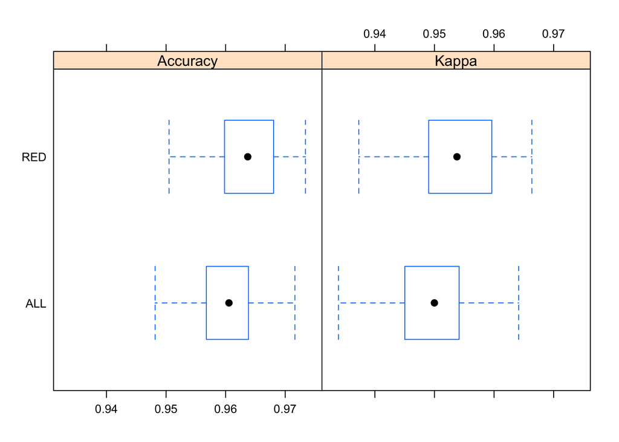

```r
bwplot(results)
```

In fact, we find that the model with reduced variables has very similar (slightly better) accuracy. Therefore, we will move forward using this reduced model (39 predictor variables and 1 outcome):

```r
training_red <- trainNoVars[,!(names(trainNoVars) %in% dropVars)]
dim(training_red)
```

```
## [1] 14622    40
```

# Cross validation

To get a prediction for our expected out of sample error, we use 3-fold cross validation. Note again that the training set has a sufficiently large number of events (14,622) that we could create a large enough testing set to determine the out of sample error. This is done as an example. First, we break the remaining training set into three pieces and train each using a random forest method:

```r
folds <- createFolds(y=training_red$classe, k=3, list=TRUE)

train1 <- training_red[-folds[[1]],]; test1  <- training_red[ folds[[1]],]

train2 <- training_red[-folds[[2]],]; test2  <- training_red[ folds[[2]],]

train3 <- training_red[-folds[[3]],]; test3  <- training_red[ folds[[3]],]

cl <- makeCluster(detectCores())
registerDoParallel(cl)

modFit1_rf <- train( classe ~ ., data=train1, method="rf", trainControl=tc)
modFit2_rf <- train( classe ~ ., data=train2, method="rf", trainControl=tc)
modFit3_rf <- train( classe ~ ., data=train3, method="rf", trainControl=tc)

stopCluster(cl)
```

Then, we test each of these models on their respective test sets and get the accuracy:

```r
cf_1 <- confusionMatrix(test1$classe,predict(modFit1_rf,test1))
cf_2 <- confusionMatrix(test2$classe,predict(modFit2_rf,test2))
cf_3 <- confusionMatrix(test3$classe,predict(modFit3_rf,test3))

acc <- c(cf_1$overall[1], cf_2$overall[1], cf_2$overall[1])
acc
```

```
##  Accuracy  Accuracy  Accuracy
## 0.9913846 0.9872794 0.9872794
```

Alternatively, we can split the remaining training set into a new training set (90%, 13,162 events) and a new testing set (10%, 1460 events):

```r
finalTrain <- createDataPartition( y=training_red$classe, p=0.9, list=FALSE )
final_train <- training_red[ finalTrain, ]
final_test <- training_red[ -finalTrain, ]

cl <- makeCluster(detectCores())
registerDoParallel(cl)

modFitFinal_rf <- train( classe ~ ., data=final_train, method="rf", trainControl=tc)

stopCluster(cl)

cf_final <- confusionMatrix(final_test$classe,predict(modFitFinal_rf,final_test))

new_acc <- cf_final$overall[1]
```

Using this method, we would predict an out of sample error of `0.0048`.

# The test set

With the test data that we put aside in the beginning, we can predict the class of each of the 20 events:

```r
answers <- predict(modFitFinal_rf,test)
answers <- as.character(answers)
```

We can store each of the results in individual files using pml_write_files function:

```r
pml_write_files = function(x){
    if( !(file.exists("test_results")) ){
        dir.create("test_results")
    }
    n = length(x)
    for(i in 1:n){
        filename = paste0("test_results/problem_id_",i,".txt")
        write.table(x[i],file=filename,quote=FALSE,row.names=FALSE,col.names=FALSE)
    }
}
```

Evaluating the function produces the requested files:

```r
source("pml_write_files.R")
pml_write_files(answers)
```

References

Velloso, Eduardo, Andreas Bulling, Hans Gellersen, Wallace Ugulino, and Hugo Fuks. 2013. “Qualitative Activity Recognition of Weight Lifting Exercises.” In *Proceedings of the 4th Augmented Human International Conference*, 116–23. AH ’13. New York, NY, USA: ACM. doi:10.1145/2459236.2459256. http://doi.acm.org/10.1145/2459236.2459256.